# Mann-Whitney U toets

Disclaimer: Het peer review proces voor deze toets is nog niet afgerond; daarom is deze pagina nog in concept.

# 1 Toepassing

Gebruik de *Mann-Whitney U toets* om te toetsen of twee ongepaarde groepen van elkaar verschillen op een ordinale[^1] variabele.[^2] Als de variabele beter als nominaal[^3] beschouwd kan worden, is de *chi-kwadraat toets voor onafhankelijkheid* of de *Fisher-Freeman-Halton exact toets* (bij een laag aantal observaties) een alternatief. Bij deze toetsen wordt echter geen rekening gehouden met de ordening van de categorieën van de ordinale variabele: de variabele wordt behandeld als een nominale variabele.

# 2 Onderwijscasus

Bij de hbo lerarenopleiding Frans leren studenten bij het vak Gesprekstechnieken om gesprekken te voeren in een praktijksetting. Aan het einde van het vak worden zij beoordeeld op basis van een mentorgesprek met een acteur waarin zij de aangeleerde vaardigheden in de praktijk kunnen toepassen. De beoordelingen bestaan uit onvoldoende, voldoende en goed. In vakevaluaties wordt vaak door mannen aangegeven dat ze het vak als erg moeilijk ervaren. Daarom wil de hoofddocent graag uitzoeken of er verschillen zijn tussen mannen en vrouwen wat betreft de beoordeling van de gesprekstechnieken.

Dit onderzoek vertaalt zich in de volgende combinatie van hypothesen, waarbij de nulhypothese zo geformuleerd is dat er geen effect of verschil is en de alternatieve hypothese zo geformuleerd is dat er wel een effect of verschil is.

*H<sub>0</sub>*: Er is geen verschil tussen mannen en vrouwen wat betreft (het gemiddelde rangnummer van) de beoordelingen van gesprekstechnieken.

*H<sub>A</sub>*: Er is een verschil tussen mannen en vrouwen wat betreft (het gemiddelde rangnummer van) de beoordelingen van gesprekstechnieken. De beoordelingen zijn hoger voor mannen of vrouwen.

# 3 Assumpties

Het meetniveau van de afhankelijke variabele is ordinaal[^4] of continu.[^5] In deze toetspagina staat een casus met ordinale data centraal; een casus met continue data met bijbehorende uitwerking is te vinden in de Mann-Whitney U toets I.

Om de *Mann-Whitney U toets* uit te voeren met een ordinale afhankelijke variabele, moet deze variabele omgezet worden in getallen. Wanneer er drie categorieën zijn, worden ze genummerd van 1 tot en met 3 op basis van de ordening van de variabele. De categorieën onvoldoende, voldoende en goed worden dan omgezet in respectievelijk 1, 2 en 3. Bij de *chi-kwadraat toets voor onafhankelijkheid* en de *Fisher-Freeman_Halton exact toets* wordt dit niet gedaan, maar wordt de ordinale variabele als nominaal[^6] beschouwd. De *Mann-Whitney U toets* maakt een rangschikking van alle observaties van beide groepen samengevoegd en telt vervolgens apart de rangnummers op voor de observaties in beide groepen. Met behulp van de groepsgroottes kan ook het gemiddelde rangnummer van beide groepen berekend worden. Het verschil tussen de gemiddelde rangnummers in beide groepen bepaalt de significantie van de toets.[^7]

# 4 Effectmaat

De p-waarde geeft aan of een (mogelijk) verschil tussen twee groepen significant is. De grootte van het verschil of effect is echter ook relevant. Een effectmaat is een gestandaardiseerde maat die de grootte van een effect weergeeft, zodat effecten van verschillende onderzoeken met elkaar vergeleken kunnen worden.[^8]

De *Mann-Whitney U toets* heeft als effectmaat *r*. Een indicatie om *r* te interpreteren is: rond 0,1 is het een klein effect, rond 0,3 is het een gemiddeld effect en rond 0,5 is het een groot effect.[^9] De effectmaat *r* wordt voor de *Mann-Whitney U toets* berekend door de *z*-waarde behorend bij de *p*-waarde van de toets te delen door de wortel van het aantal observaties, i.e. $\frac{z}{\sqrt{N}}$.[^10] Een correlatie tussen twee variabelen wordt vaak ook aangeduid met het symbool *r*. Beide zijn effectmaten, maar er is verder geen verband tussen de correlatie en de effectmaat van de *Wilcoxon signed rank toets*.

# 5 Uitvoering

Er is een dataset `Beoordelingen_gesprekstechnieken` ingeladen met de beoordelingen van studenten voor het vak Gesprekstechnieken.

## 5.1 De data bekijken

Gebruik `head()` en `tail()` om de structuur van de data te bekijken.

```r
## Eerste 6 observaties
head(Beoordelingen_gesprekstechnieken)
##   Studentnummer Geslacht Beoordeling
## 1       3909362      Man        Goed
## 2       3731799      Man        Goed
## 3       3623196      Man        Goed
## 4       3720223      Man   Voldoende
## 5       3468737      Man   Voldoende
## 6       3327754      Man        Goed
## Eerste 6 observaties
tail(Beoordelingen_gesprekstechnieken)
##    Studentnummer Geslacht Beoordeling
## 75       3088606    Vrouw   Voldoende
## 76       3182503    Vrouw   Voldoende
## 77       3814744    Vrouw        Goed
## 78       3759883    Vrouw        Goed
## 79       3228871    Vrouw        Goed
## 80       3863377    Vrouw        Goed
```

Een kruistabel geeft de aantallen observaties weer voor de combinaties van de categorieën van de variabelen `Geslacht` en `Beoordeling`. In feite laat dit zien welke beoordelingen mannen en vrouwen krijgen. Maak de kruistabel met de functie `table()` met als argumenten de variabele `Beoordelingen_gesprekstechnieken$Geslacht` en de variabele `Beoordelingen_gesprekstechnieken$Beoordeling`.

```r
## Maak een kruistabel
Beoordelingen_kruistabel <- table(Beoordelingen_gesprekstechnieken$Geslacht, Beoordelingen_gesprekstechnieken$Beoordeling)

## Bepaal de volgorde van de beoordelingen
Volgorde <- c("Onvoldoende", "Voldoende", "Goed")

## Print de kruistabel
print(Beoordelingen_kruistabel[,Volgorde])
```

```
##
##         Onvoldoende Voldoende Goed
##   Man             5        10   15
##   Vrouw           5        17   28
```

```r
## Print een tabel met proporties; het tweede argument `1` zorgt ervoor dat de
## proporties per kolom berekend worden
prop.table(Beoordelingen_kruistabel[,Volgorde], 1)
```

```
##
##         Onvoldoende Voldoende      Goed
##   Man     0.1666667 0.3333333 0.5000000
##   Vrouw   0.1000000 0.3400000 0.5600000
```

De kruistabel en bijbehorende kruistabel met proporties laten zien dat de gesprekstechnieken van vrouwen relatief iets vaker als goed beoordeeld worden en iets minder vaak als onvoldoende in vergelijking met de gesprechtstechnieken van mannen.

## 5.2 De data visualiseren

Maak een staafdiagram om de verdeling van de beoordelingen voor het van Gesprekstechnieken van mannen en vrouwen visueel weer te geven.

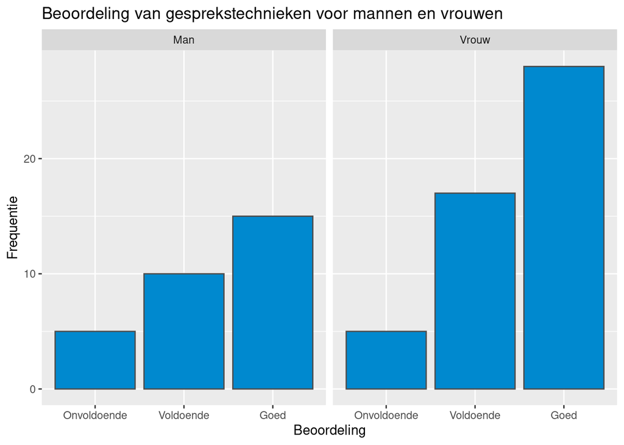

```r
## Histogram met ggplot2
library(ggplot2)

ggplot(Beoordelingen_gesprekstechnieken,
  aes(Beoordeling)) +
  geom_bar(color = "grey30",
                 fill = "#0089CF") +
  scale_x_discrete(limits = c("Onvoldoende", "Voldoende", "Goed")) +
  facet_wrap(~ Geslacht) +
  ylab("Frequentie") +
  labs(title = "Beoordeling van gesprekstechnieken voor mannen en vrouwen")
```

Bij zowel mannen als vrouwen krijgen de meeste studenten de beoordeling goed. Het aantal studenten waarvan de gesprekstechnieken als onvoldoende wordt beoordeeld is bij beide groepen het laagst.